# Metasploitable2 Installation Guide

### Installing Metasploitable2 in VirtualBox

Metasploitable2 is a Linux virtual machine configured to have as many open services and vulnerabilities as possible. You can download it from Rapid7 [here](https://docs.rapid7.com/metasploit/metasploitable-2). (It’s about 900 MB.)

The zip file contains a virtual hard disk that we will load in VirtualBox. Unzip the file to get started, then open VirtualBox and click `New`:

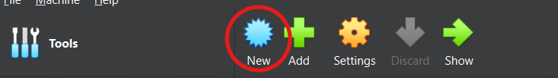

Name it something you’ll remember and select a Type of “Linux”, then click next:

[figure not shown]

Set your desired RAM and CPU settings on the next page, then on the third page, click `Use an Existing Virtual Hard Disk File` and click on the button to choose a file:

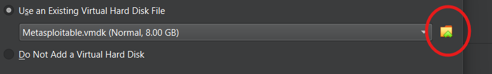

Now click `Add`

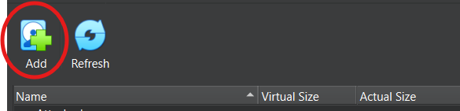

Now click `Next` and `Finish`, and you have a freshly installed Metasploitable2 machine in your VirtualBox.

### Adding Kali and Metasploitable2 to the same subnet

Now we’ll put your Kali box and the Metasploitable2 box in the same subnet. For convenience, I like to group virtual machines so I can visually see which ones are connected:

[figure not shown]

To get started, go to `File > Preferences` and make sure the `Expert` toggle is set.

Now go to `File > Tools > Network Manager` and click `Create`

[figure not shown]

You’ll get a UAC prompt from Windows. Make sure that you click okay, and you should see an extra “VirtualBox Host-Only Ethernet Adapter” appear in the list. At the bottom, click on the tab for DHCP Server and check the box that says `Enable server`:

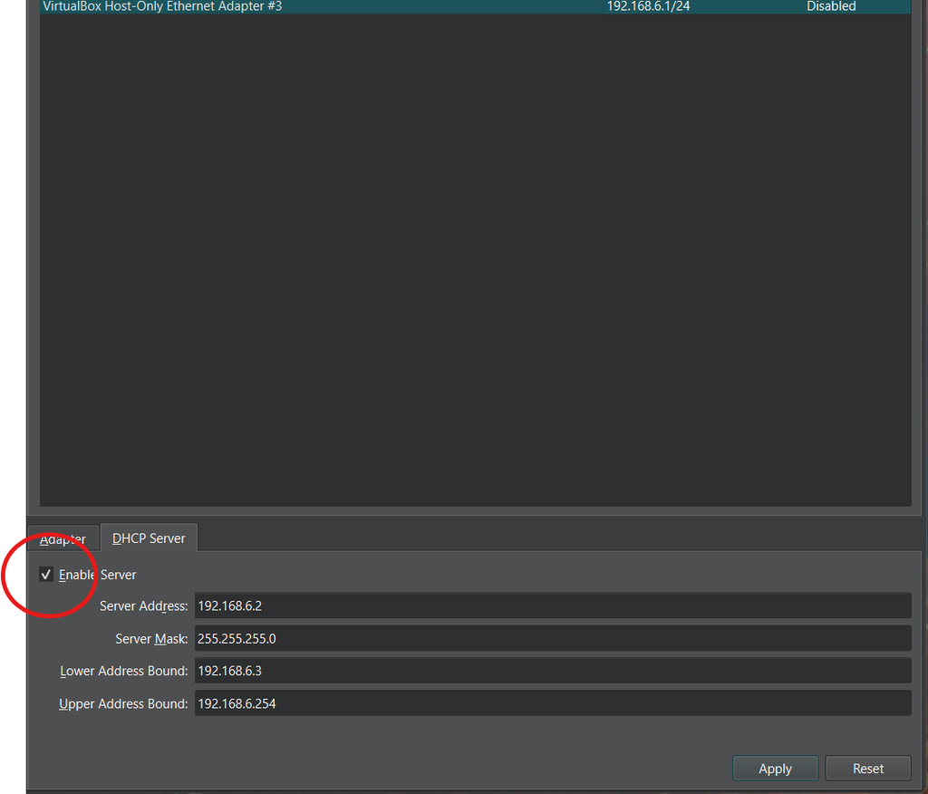

Go back to the adapter tab and toggle `Configure Adapter Automatically`

Now, return to your Metasploitable2 machine and click on `Settings`:

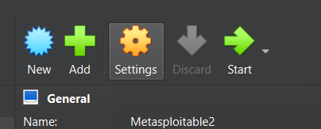

Scroll down to `Network`, and disable `Adapter #1` (the default adapter that VirtualBox sets up that’s internet-connected). Instead, click on the tab for whichever adapter you just set up (in my case, it’s adapter #3):

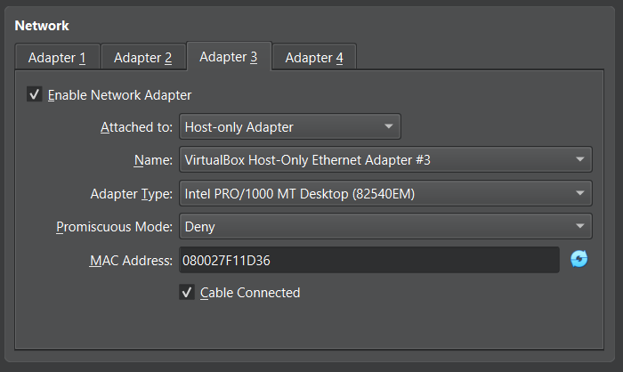

Make sure you set this to `Host-only adapter` and change the name to your intended adapter. Once you’ve done that, just click `OK` and repeat the process for your Kali machine. By selecting the same adapter for each machine, they will be using the same DHCP server and will communicate over the subnet, so they will share an internal network.

[figure not shown]

### Getting Shell with Netcat

Now if you want to you can access the Metasploitable2 box by using `netcat`:

First set up a listening port on the target machine that will execute bash:

[figure not shown]

Then take your target machine’s IP address you obtained with `ip addr` and connect via netcat:

[figure not shown]